# Homework 4

Yitao Tian

2022-11-11

# Question 1

## 1(a)

```r
parsum <- function(x, n) {
    partial <- 0
    for (i in 1:n) {
       partial <- partial + (exp(-x) * x^i) / factorial(i)
    }
    return(partial)
}
parsum(x=10, n=15)
```

```
## [1] 0.9512142
```

## 1(b)

```r
Printchar <- function(Lst) {
   for (item in Lst) {
      if (is.character(item)) {
        print(item)
      }
   }
}
Printchar(Lst = list("A", 2, "B", 4, "ANDY"))
```

```
## [1] "A"
## [1] "B"
## [1] "ANDY"
```

## 1(c)

```r
series <- function(x, n) {
   partial <- 1
   for (i in 1:n) {
    partial <- partial + (x^i) / (i)
   }
   return(partial)
}
series(x=2, n=5)
```

```
## [1] 18.06667
```

# Question 2

## 2(a)

```r
restaurant <- read.table(
    "X:/Downloads - Data Drive/Restaurant.txt",
    header=TRUE
)
datatable <- xtabs(
    formula = Count ~ (Age_Group + Food_preference),
    data = restaurant
)
datatable
```

```
##          Food_preference
## Age_Group Fish Pasta Steak Veggie
##   Adults   105    72    72     75
##   Kids      27    22    12     21
##   Seniors   94   108    86     42
```

## 2(b)

```r
food_pref <- margin.table(
    x = datatable,
    margin = c("Food_preference")
)
(food_pref[["Fish"]] + food_pref[["Steak"]]) / sum(food_pref)
```

```
## [1] 0.5380435
```

## 2(c)

```r
age <- prop.table(
    x = datatable,
    margin = c("Food_preference")
)
age[, "Fish"]
```

```
##    Adults      Kids   Seniors
## 0.4646018 0.1194690 0.4159292
```

## 2(d)

Null Hypothesis: no relation

Alternative Hypothesis: there is a relation between Food preference and Age group

Alpha: 0.05

```r
chisq <- chisq.test(datatable)
chisq
```

```
##
##  Pearson's Chi-squared test
##
## data:  datatable
## X-squared = 23.243, df = 6, p-value = 0.000719
```

The p-value of this test was 0.000719, which is less than the alpha of 0.05.

Therefore, we have sufficient evidence to reject the null hypothesis, and conclude that there is a relation between Food preference and Age group for this sample.

## 2(e)

```r
round(chisq$expected, 0)
```

```
##          Food_preference
## Age_Group Fish Pasta Steak Veggie
##   Adults    99    89    75     61
##   Kids      25    23    19     15
##   Seniors  101    91    76     62
```

```r
chisq$observed
```

```
##          Food_preference
## Age_Group Fish Pasta Steak Veggie
##   Adults   105    72    72     75
##   Kids      27    22    12     21
##   Seniors   94   108    86     42
```

- There are two categorical variables being compared: Food preference and Age group.
- There are a minimum of 10 observations per combination of categories (min. 12).
- The sample was randomly selected (“A survey of 736 randomly chosen customers…”).
- The sample size is greater than 50 (sample size: 736).
- The items in the samples are independent.

## 2(f)

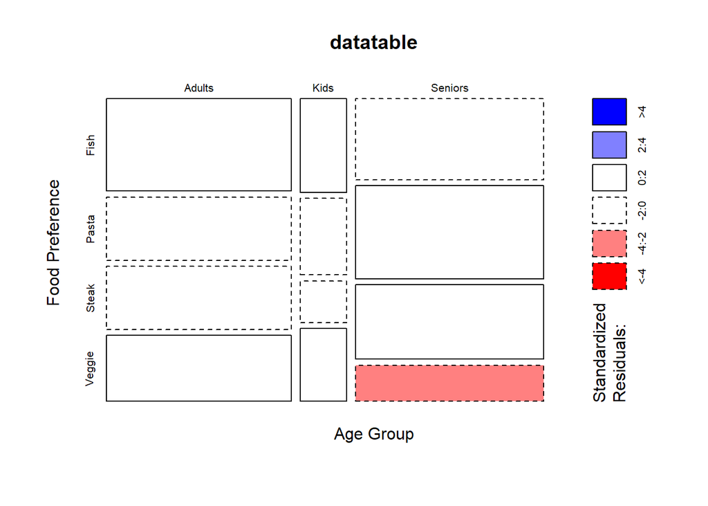

```r
mosaicplot(
    datatable,
    shade = TRUE,
    xlab = "Age Group",
    ylab = "Food Preference"
)
```

More adults and seniors dine here than children.

Seniors eat more pasta than kids and adults.

Kids eat more veggies and fish than adults and seniors.

Kids eat the least steak out of all age groups.

Seniors eat the least veggies out of all age groups.

# Question 3

## 3(a)

```r
identification <- array(
    data=c(132, 176, 127, 42, 6, 12, 172, 129, 130, 56, 4, 15),
    dim=c(3, 2, 2),
    dimnames=list(
        "Party Identification" = as.factor(c("Democrat", "Republican", "Independent")),
        "Race" = as.factor(c("White", "Black")),
        "Gender" = as.factor(c("Female", "Male"))
    )
)
identification
```

```
## , , Gender = Female
##
##                     Race
## Party Identification White Black
##          Democrat      132    42
##          Republican    176     6
##          Independent   127    12
##
## , , Gender = Male
##
##                     Race
## Party Identification White Black
##          Democrat      172    56
##          Republican    129     4
##          Independent   130    15
```

## 3(b)

```r
margin.table(
    identification,
    margin = c("Race", "Party Identification")
)
```

```
##        Party Identification
## Race    Democrat Republican Independent
##   White      304        305         257
##   Black       98         10          27
```

## 3(c)

Null Hypothesis: no association

Alpha: 0.05

```r
chisq.test(as.matrix(identification))
```

```
##
##  Chi-squared test for given probabilities
##
## data:  as.matrix(identification)
## X-squared = 593.11, df = 11, p-value < 2.2e-16
```

## 3(d)

```r
prop.table(
    identification,
    margin = c(2, 3)
)[2,1,]
```

```
##    Female      Male
## 0.4045977 0.2993039
```